# Individual differences

In **Pilot 1**, there are 41 subjects who did the curiosity personal trait questionaire. The following analysis will only include these subjects who had personal trait scores.

# 1 Relationship between trait score and slope of curiosity-memory relationship

## 1.1 Outside

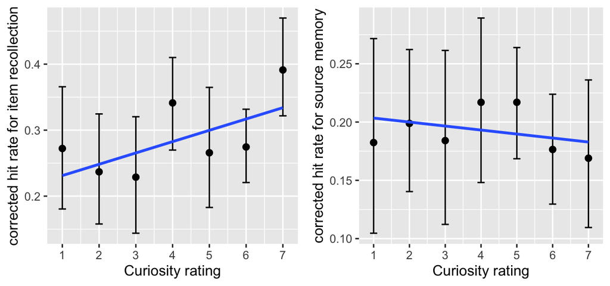

### 1.1.1 Item recollection

#### 1.1.1.1 Correlation with the average score

```
##                  Model df       AIC       BIC   logLik   Test  L.Ratio
## baseline.rating      1  3 -76.88894 -67.83710 41.44447
## rating.intercept     2  4 -79.54304 -67.47392 43.77152 1 vs 2 4.654096
## rating.slope         3  6 -78.09156 -59.98788 45.04578 2 vs 3 2.548527
## tr.intercept         4  7 -76.31966 -55.19870 45.15983 3 vs 4 0.228096
## tr.slope             5  8 -75.07944 -50.94120 45.53972 4 vs 5 0.759780
##                  p-value
## baseline.rating
## rating.intercept  0.0310
## rating.slope      0.2796
## tr.intercept      0.6329
## tr.slope          0.3834
```

#### 1.1.1.2 Correlation with the PC score

```
##                  Model df       AIC       BIC   logLik   Test  L.Ratio
## baseline.rating      1  3 -76.88894 -67.83710 41.44447
## rating.intercept     2  4 -79.54304 -67.47392 43.77152 1 vs 2 4.654096
## rating.slope         3  6 -78.09156 -59.98788 45.04578 2 vs 3 2.548527
## PC.intercept         4  7 -76.55856 -55.43760 45.27928 3 vs 4 0.467000
## PC.slope             5  8 -74.95885 -50.82061 45.47943 4 vs 5 0.400290
##                  p-value
## baseline.rating
## rating.intercept  0.0310
## rating.slope      0.2796
## PC.intercept      0.4944
## PC.slope          0.5269
```

#### 1.1.1.3 Correlation with the EC score

```
##                  Model df       AIC       BIC   logLik   Test  L.Ratio
## baseline.rating      1  3 -76.88894 -67.83710 41.44447
## rating.intercept     2  4 -79.54304 -67.47392 43.77152 1 vs 2 4.654096
## rating.slope         3  6 -78.09156 -59.98788 45.04578 2 vs 3 2.548527
## EC.intercept         4  7 -76.11869 -54.99773 45.05934 3 vs 4 0.027123
## EC.slope             5  8 -74.99963 -50.86140 45.49982 4 vs 5 0.880949
##                  p-value
## baseline.rating
## rating.intercept  0.0310
## rating.slope      0.2796
## EC.intercept      0.8692
## EC.slope          0.3479
```

### 1.1.2 Source memory

#### 1.1.2.1 Correlation with the average score

```
##                  Model df       AIC       BIC   logLik   Test    L.Ratio
## baseline.rating      1  3 -141.2951 -132.2432 73.64754
## rating.intercept     2  4 -139.5848 -127.5156 73.79238 1 vs 2 0.28969217
## rating.slope         3  6 -135.5841 -117.4804 73.79205 2 vs 3 0.00066313
## tr.intercept         4  7 -133.8305 -112.7096 73.91526 3 vs 4 0.24641982
## tr.slope             5  8 -131.8795 -107.7412 73.93973 4 vs 5 0.04894161
##                  p-value
## baseline.rating
## rating.intercept  0.5904
## rating.slope      0.9997
## tr.intercept      0.6196
## tr.slope          0.8249
```

#### 1.1.2.2 Correlation with the PC score

```
##                  Model df       AIC       BIC   logLik   Test    L.Ratio
## baseline.rating      1  3 -141.2951 -132.2432 73.64754
## rating.intercept     2  4 -139.5848 -127.5156 73.79238 1 vs 2 0.28969217
## rating.slope         3  6 -135.5841 -117.4804 73.79205 2 vs 3 0.00066313
## PC.intercept         4  7 -133.5854 -112.4645 73.79271 3 vs 4 0.00131906
## PC.slope             5  8 -131.7466 -107.6084 73.87332 4 vs 5 0.16120991
##                  p-value
## baseline.rating
## rating.intercept  0.5904
## rating.slope      0.9997
## PC.intercept      0.9710
## PC.slope          0.6880
```

#### 1.1.2.3 Correlation with the EC score

```
##                  Model df       AIC       BIC   logLik   Test   L.Ratio
## baseline.rating      1  3 -141.2951 -132.2432 73.64754
## rating.intercept     2  4 -139.5848 -127.5156 73.79238 1 vs 2 0.2896922
## rating.slope         3  6 -135.5841 -117.4804 73.79205 2 vs 3 0.0006631
## EC.intercept         4  7 -134.3350 -113.2140 74.16748 3 vs 4 0.7508613
## EC.slope             5  8 -132.3349 -108.1967 74.16745 4 vs 5 0.0000561
##                  p-value
## baseline.rating
## rating.intercept  0.5904
## rating.slope      0.9997
## EC.intercept      0.3862
## EC.slope          0.9940
```

## 1.2 Inside

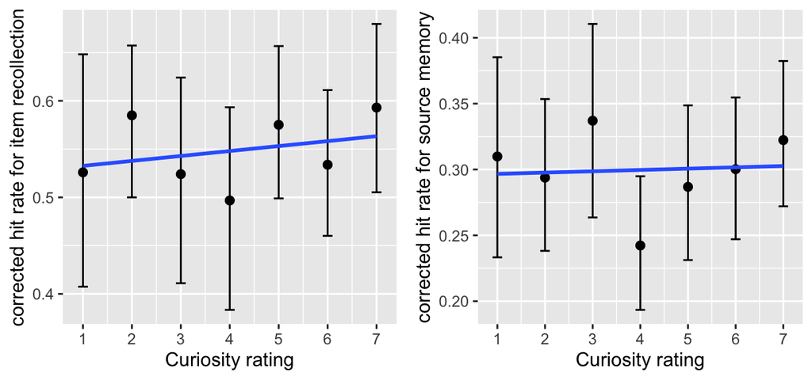

### 1.2.1 Item recollection

#### 1.2.1.1 Correlation with the average score

```
##                  Model df        AIC       BIC    logLik   Test  L.Ratio
## baseline.rating      1  3 -13.209121 -3.139363  9.604561
## rating.intercept     2  4 -11.406713  2.019632  9.703356 1 vs 2 0.197592
## rating.slope         3  6  -8.172736 11.966782 10.086368 2 vs 3 0.766023
## tr.intercept         4  7  -6.219731 17.276373 10.109866 3 vs 4 0.046995
## tr.slope             5  8  -8.787450 18.065240 12.393725 4 vs 5 4.567719
##                  p-value
## baseline.rating
## rating.intercept  0.6567
## rating.slope      0.6818
## tr.intercept      0.8284
## tr.slope          0.0326
```

```
##                    Value  Std.Error  DF    t-value    p-value
## (Intercept)   0.12373265 0.26067133 169  0.4746692 0.63563557
## CurRating     0.10505471 0.04858078 169  2.1624745 0.03198741
## GN            0.14113771 0.08884701  39  1.5885476 0.12023781
## CurRating:GN -0.03509937 0.01646074 169 -2.1323081 0.03442590
```

#### 1.2.1.2 Correlation with the PC score

```
##                  Model df        AIC       BIC    logLik   Test  L.Ratio
## baseline.rating      1  3 -13.209121 -3.139363  9.604561
## rating.intercept     2  4 -11.406713  2.019632  9.703356 1 vs 2 0.197592
## rating.slope         3  6  -8.172736 11.966782 10.086368 2 vs 3 0.766023
## PC.intercept         4  7  -6.587584 16.908519 10.293792 3 vs 4 0.414848
## PC.slope             5  8  -9.781505 17.071186 12.890752 4 vs 5 5.193920
##                  p-value
## baseline.rating
## rating.intercept  0.6567
## rating.slope      0.6818
## PC.intercept      0.5195
## PC.slope          0.0227
```

```
##                    Value  Std.Error  DF    t-value    p-value
## (Intercept)   0.05289213 0.24201820 169  0.2185461 0.82726735
## CurRating     0.10320688 0.04432761 169  2.3282752 0.02108178
## PC            0.16337385 0.08129786  39  2.0095715 0.05143195
## CurRating:PC -0.03399855 0.01479275 169 -2.2983246 0.02276828
```

#### 1.2.1.3 Correlation with the EC score

```
##                  Model df        AIC       BIC    logLik   Test   L.Ratio
## baseline.rating      1  3 -13.209121 -3.139363  9.604561
## rating.intercept     2  4 -11.406713  2.019632  9.703356 1 vs 2 0.1975915
## rating.slope         3  6  -8.172736 11.966782 10.086368 2 vs 3 0.7660233
## EC.intercept         4  7  -6.309313 17.186791 10.154657 3 vs 4 0.1365769
## EC.slope             5  8  -6.835171 20.017519 11.417585 4 vs 5 2.5258577
##                  p-value
## baseline.rating
## rating.intercept  0.6567
## rating.slope      0.6818
## EC.intercept      0.7117
## EC.slope          0.1120
```

```
##                    Value  Std.Error  DF    t-value   p-value
## (Intercept)   0.33380555 0.22986606 169  1.4521742 0.1483072
## CurRating     0.07031952 0.04335159 169  1.6220748 0.1066514
## EC            0.06967369 0.07903070  39  0.8816028 0.3833929
## CurRating:EC -0.02347606 0.01482843 169 -1.5831791 0.1152502
```

### 1.2.2 Source memory

#### 1.2.2.1 Correlation with the average score

```
##                  Model df       AIC       BIC   logLik   Test   L.Ratio
## baseline.rating      1  3 -142.1869 -132.1171 74.09344
## rating.intercept     2  4 -140.2752 -126.8488 74.13758 1 vs 2 0.0882748
## rating.slope         3  6 -137.4415 -117.3020 74.72075 2 vs 3 1.1663318
## tr.intercept         4  7 -135.9128 -112.4167 74.95641 3 vs 4 0.4713379
## tr.slope             5  8 -134.7207 -107.8680 75.36034 4 vs 5 0.8078528
##                  p-value
## baseline.rating
## rating.intercept  0.7664
## rating.slope      0.5581
## tr.intercept      0.4924
## tr.slope          0.3688
```

#### 1.2.2.2 Correlation with the PC score

```
##                  Model df       AIC       BIC   logLik   Test   L.Ratio
## baseline.rating      1  3 -142.1869 -132.1171 74.09344
## rating.intercept     2  4 -140.2752 -126.8488 74.13758 1 vs 2 0.0882748
## rating.slope         3  6 -137.4415 -117.3020 74.72075 2 vs 3 1.1663318
## PC.intercept         4  7 -135.4455 -111.9494 74.72275 3 vs 4 0.0040153
## PC.slope             5  8 -133.4570 -106.6043 74.72848 4 vs 5 0.0114566
##                  p-value
## baseline.rating
## rating.intercept  0.7664
## rating.slope      0.5581
## PC.intercept      0.9495
## PC.slope          0.9148
```

```
##                    Value   Std.Error  DF     t-value     p-value
## (Intercept)  0.289040661 0.093789716 170  3.08179482 0.002400892
## CurRating    0.002686256 0.006850984 170  0.39209790 0.695477000
## PC          -0.001884326 0.029919657  39 -0.06297954 0.950104478
```

#### 1.2.2.3 Correlation with the EC score

```
##                  Model df       AIC       BIC   logLik   Test   L.Ratio
## baseline.rating      1  3 -142.1869 -132.1171 74.09344
## rating.intercept     2  4 -140.2752 -126.8488 74.13758 1 vs 2 0.0882748
## rating.slope         3  6 -137.4415 -117.3020 74.72075 2 vs 3 1.1663318
## EC.intercept         4  7 -136.8533 -113.3572 75.42664 3 vs 4 1.4117812
## EC.slope             5  8 -137.1189 -110.2662 76.55943 4 vs 5 2.2655831
##                  p-value
## baseline.rating
## rating.intercept  0.7664
## rating.slope      0.5581
## EC.intercept      0.2348
## EC.slope          0.1323
```

# 2 Relationship between trait score and curiosity ratings

## 2.1 Across all the rooms

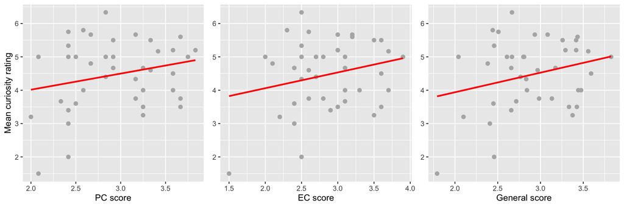

```r
cor.test(trait.ratings$meanCurRating, trait.ratings$PC, method = "pearson")
```

```
##
##  Pearson's product-moment correlation
##
## data:  trait.ratings$meanCurRating and trait.ratings$PC
## t = 1.5065, df = 38, p-value = 0.1402
## alternative hypothesis: true correlation is not equal to 0
## 95 percent confidence interval:
##  -0.08003037  0.51110939
## sample estimates:
##       cor
## 0.2373973
```

```r
cor.test(trait.ratings$meanCurRating, trait.ratings$EC, method = "pearson")
```

```
##
##  Pearson's product-moment correlation
##
## data:  trait.ratings$meanCurRating and trait.ratings$EC
## t = 1.5162, df = 38, p-value = 0.1378
## alternative hypothesis: true correlation is not equal to 0
## 95 percent confidence interval:
##  -0.07851453  0.51223545
## sample estimates:
##       cor
## 0.2388363
```

```r
cor.test(trait.ratings$meanCurRating, trait.ratings$GN, method = "pearson")
```

```
##
##  Pearson's product-moment correlation
##
## data:  trait.ratings$meanCurRating and trait.ratings$GN
## t = 1.6881, df = 38, p-value = 0.09958
## alternative hypothesis: true correlation is not equal to 0
## 95 percent confidence interval:
##  -0.05163276  0.53187304
## sample estimates:
##       cor
## 0.2641248
```

## 2.2 Only for the *novel* rooms

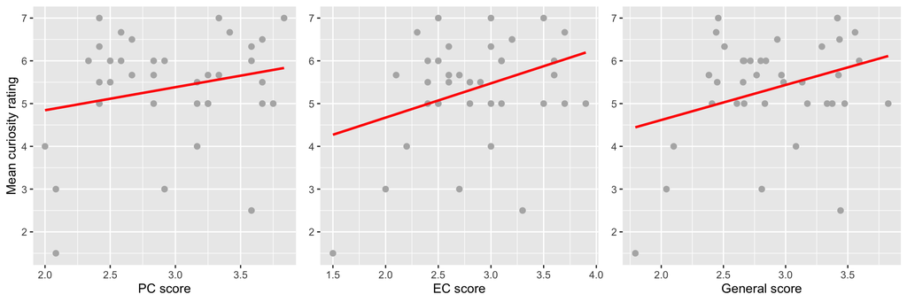

```
##
##  Pearson's product-moment correlation
##
## data:  trait.ratings.novel$meanCurRating and trait.ratings.novel$PC
## t = 1.3968, df = 36, p-value = 0.171
## alternative hypothesis: true correlation is not equal to 0
## 95 percent confidence interval:
##  -0.1002065  0.5094930
## sample estimates:
##       cor
## 0.2267403
```

```
##
##  Pearson's product-moment correlation
##
## data:  trait.ratings.novel$meanCurRating and trait.ratings.novel$EC
## t = 2.1735, df = 36, p-value = 0.0364
## alternative hypothesis: true correlation is not equal to 0
## 95 percent confidence interval:
##  0.02345727 0.59543867
## sample estimates:
##       cor
## 0.3405866
```

```
##
##  Pearson's product-moment correlation
##
## data:  trait.ratings.novel$meanCurRating and trait.ratings.novel$GN
## t = 1.9827, df = 36, p-value = 0.05507
## alternative hypothesis: true correlation is not equal to 0
## 95 percent confidence interval:
##  -0.006573817  0.575705199
## sample estimates:
##       cor
## 0.3137689
```

# 3 Relationship between trait score and memory performance

Here *memory performance* refers to the average corrected hit rate for “seen” response for items and average corrected hit rate for source memory.

## 3.1 Outside

### 3.1.1 Item recollection

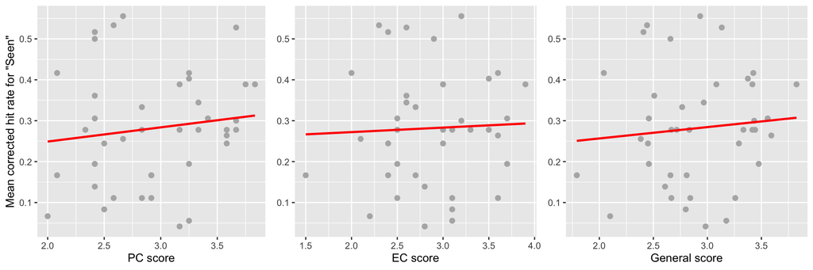

```
##
##  Pearson's product-moment correlation
##
## data:  outside.hit.rate.trait$meanSAcc and outside.hit.rate.trait$PC
## t = 0.80176, df = 38, p-value = 0.4277
## alternative hypothesis: true correlation is not equal to 0
## 95 percent confidence interval:
##  -0.1901736  0.4234718
## sample estimates:
##       cor
## 0.1289764
```

```
##
##  Pearson's product-moment correlation
##
## data:  outside.hit.rate.trait$meanSAcc and outside.hit.rate.trait$EC
## t = 0.26013, df = 38, p-value = 0.7962
## alternative hypothesis: true correlation is not equal to 0
## 95 percent confidence interval:
##  -0.2729323  0.3490862
## sample estimates:
##        cor
## 0.04216168
```

```
##
##  Pearson's product-moment correlation
##
## data:  outside.hit.rate.trait$meanSAcc and outside.hit.rate.trait$GN
## t = 0.58354, df = 38, p-value = 0.563
## alternative hypothesis: true correlation is not equal to 0
## 95 percent confidence interval:
##  -0.2238391  0.3941789
## sample estimates:
##        cor
## 0.09424154
```

### 3.1.2 Source memory

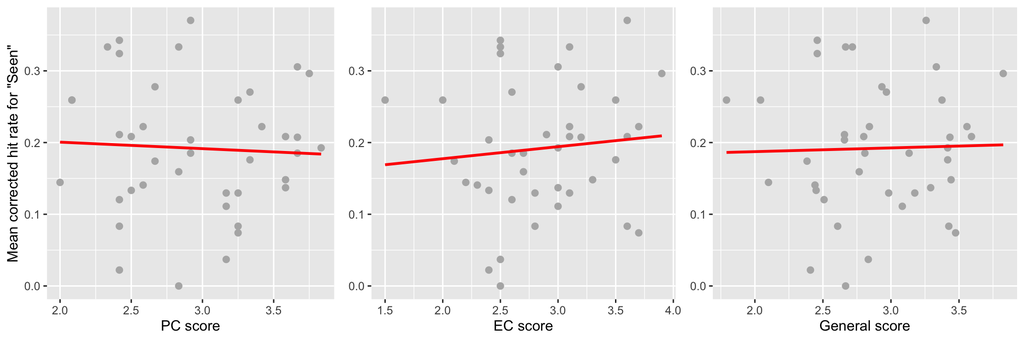

```
##
##  Pearson's product-moment correlation
##
## data:  outside.hit.rate.trait$meanSrcAcc and outside.hit.rate.trait$PC
## t = -0.31723, df = 38, p-value = 0.7528
## alternative hypothesis: true correlation is not equal to 0
## 95 percent confidence interval:
##  -0.3571844  0.2643480
## sample estimates:
##         cor
## -0.05139345
```

```
##
##  Pearson's product-moment correlation
##
## data:  outside.hit.rate.trait$meanSrcAcc and outside.hit.rate.trait$EC
## t = 0.60667, df = 38, p-value = 0.5477
## alternative hypothesis: true correlation is not equal to 0
## 95 percent confidence interval:
##  -0.2202889  0.3973283
## sample estimates:
##        cor
## 0.09794134
```

```
##
##  Pearson's product-moment correlation
##
## data:  outside.hit.rate.trait$meanSrcAcc and outside.hit.rate.trait$GN
## t = 0.1663, df = 38, p-value = 0.8688
## alternative hypothesis: true correlation is not equal to 0
## 95 percent confidence interval:
##  -0.2869530  0.3356565
## sample estimates:
##        cor
## 0.02696684
```

## 3.2 Inside

### 3.2.1 Item recollection

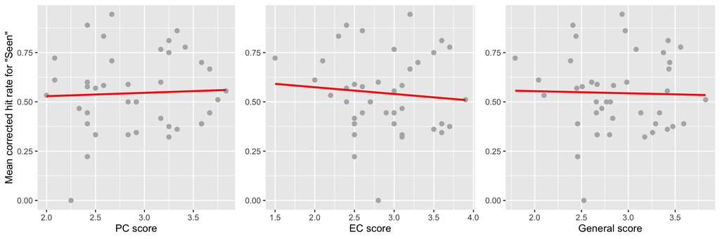

```
##
##  Pearson's product-moment correlation
##
## data:  inside.hit.rate.trait$meanSAcc and inside.hit.rate.trait$PC
## t = 0.28434, df = 39, p-value = 0.7777
## alternative hypothesis: true correlation is not equal to 0
## 95 percent confidence interval:
##  -0.2658880  0.3482603
## sample estimates:
##        cor
## 0.04548298
```

```
##
##  Pearson's product-moment correlation
##
## data:  inside.hit.rate.trait$meanSAcc and inside.hit.rate.trait$EC
## t = -0.5723, df = 39, p-value = 0.5704
## alternative hypothesis: true correlation is not equal to 0
## 95 percent confidence interval:
##  -0.3880149  0.2226431
## sample estimates:
##         cor
## -0.09125819
```

```
##
##  Pearson's product-moment correlation
##
## data:  inside.hit.rate.trait$meanSAcc and inside.hit.rate.trait$GN
## t = -0.16057, df = 39, p-value = 0.8733
## alternative hypothesis: true correlation is not equal to 0
## 95 percent confidence interval:
##  -0.3307379  0.2841950
## sample estimates:
##         cor
## -0.02570273
```

### 3.2.2 Source memory

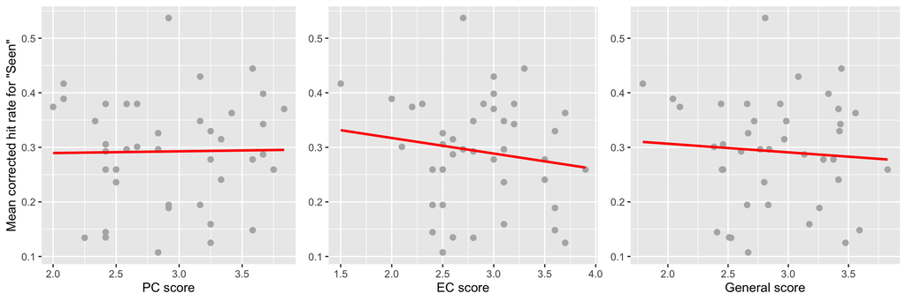

```
##
##  Pearson's product-moment correlation
##
## data:  inside.hit.rate.trait$meanSrcAcc and inside.hit.rate.trait$PC
## t = 0.10295, df = 39, p-value = 0.9185
## alternative hypothesis: true correlation is not equal to 0
## 95 percent confidence interval:
##  -0.2926517  0.3224979
## sample estimates:
##       cor
## 0.0164828
```

```
##
##  Pearson's product-moment correlation
##
## data:  inside.hit.rate.trait$meanSrcAcc and inside.hit.rate.trait$EC
## t = -0.94894, df = 39, p-value = 0.3485
## alternative hypothesis: true correlation is not equal to 0
## 95 percent confidence interval:
##  -0.4376506  0.1650514
## sample estimates:
##        cor
## -0.1502273
```

```
##
##  Pearson's product-moment correlation
##
## data:  inside.hit.rate.trait$meanSrcAcc and inside.hit.rate.trait$GN
## t = -0.46772, df = 39, p-value = 0.6426
## alternative hypothesis: true correlation is not equal to 0
## 95 percent confidence interval:
##  -0.3737483  0.2384437
## sample estimates:
##         cor
## -0.07468543
```

# 4 Relationship between trait score and memory performance within *Novel* rooms

Here *memory performance* refers to the average corrected hit rate for “seen” response for items and average corrected hit rate for source memory.

## 4.1 Outside

### 4.1.1 Item recollection

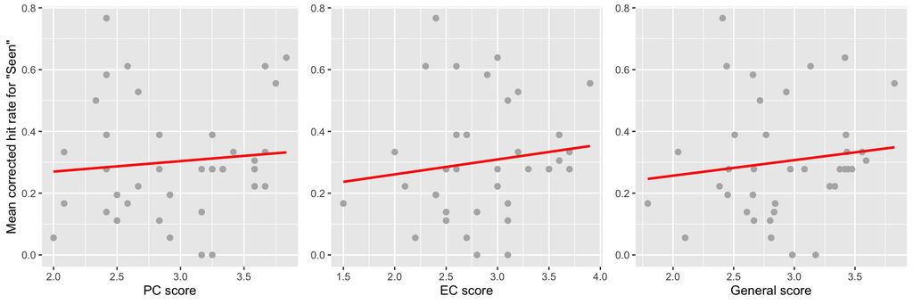

```
##
##  Pearson's product-moment correlation
##
## data:  outside.hit.rate.trait.novel$meanSAcc and outside.hit.rate.trait.novel$PC
## t = 0.57641, df = 36, p-value = 0.5679
## alternative hypothesis: true correlation is not equal to 0
## 95 percent confidence interval:
##  -0.2311204  0.4029921
## sample estimates:
##        cor
## 0.09562854
```

```
##
##  Pearson's product-moment correlation
##
## data:  outside.hit.rate.trait.novel$meanSAcc and outside.hit.rate.trait.novel$EC
## t = 0.83281, df = 36, p-value = 0.4104
## alternative hypothesis: true correlation is not equal to 0
## 95 percent confidence interval:
##  -0.1905756  0.4379200
## sample estimates:
##       cor
## 0.1374838
```

```
##
##  Pearson's product-moment correlation
##
## data:  outside.hit.rate.trait.novel$meanSAcc and outside.hit.rate.trait.novel$GN
## t = 0.77998, df = 36, p-value = 0.4405
## alternative hypothesis: true correlation is not equal to 0
## 95 percent confidence interval:
##  -0.1989707  0.4308404
## sample estimates:
##       cor
## 0.1289124
```

### 4.1.2 Source memory

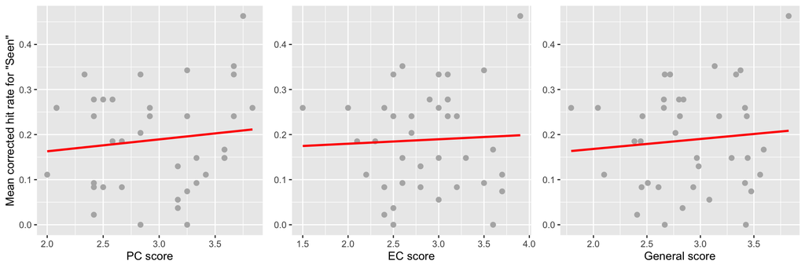

```
##
##  Pearson's product-moment correlation
##
## data:  outside.hit.rate.trait.novel$meanSrcAcc and outside.hit.rate.trait.novel$PC
## t = 0.74839, df = 36, p-value = 0.4591
## alternative hypothesis: true correlation is not equal to 0
## 95 percent confidence interval:
##  -0.2039827  0.4265764
## sample estimates:
##       cor
## 0.1237718
```

```
##
##  Pearson's product-moment correlation
##
## data:  outside.hit.rate.trait.novel$meanSrcAcc and outside.hit.rate.trait.novel$EC
## t = 0.28174, df = 36, p-value = 0.7798
## alternative hypothesis: true correlation is not equal to 0
## 95 percent confidence interval:
##  -0.2769305  0.3611730
## sample estimates:
##        cor
## 0.04690542
```

```
##
##  Pearson's product-moment correlation
##
## data:  outside.hit.rate.trait.novel$meanSrcAcc and outside.hit.rate.trait.novel$GN
## t = 0.567, df = 36, p-value = 0.5742
## alternative hypothesis: true correlation is not equal to 0
## 95 percent confidence interval:
##  -0.2325978  0.4016834
## sample estimates:
##        cor
## 0.09408118
```

## 4.2 Inside

### 4.2.1 Item recollection

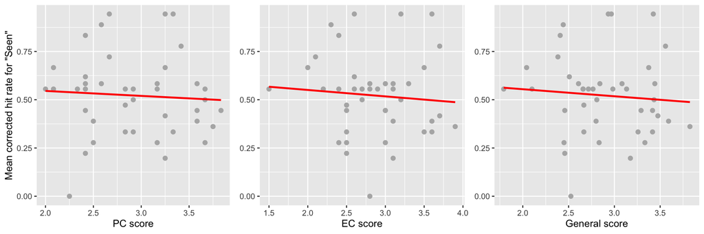

```
##
##  Pearson's product-moment correlation
##
## data:  inside.hit.rate.trait.novel$meanSAcc and inside.hit.rate.trait.novel$PC
## t = -0.39912, df = 39, p-value = 0.692
## alternative hypothesis: true correlation is not equal to 0
## 95 percent confidence interval:
##  -0.3642833  0.2487506
## sample estimates:
##         cor
## -0.06378091
```

```
##
##  Pearson's product-moment correlation
##
## data:  inside.hit.rate.trait.novel$meanSAcc and inside.hit.rate.trait.novel$EC
## t = -0.51981, df = 39, p-value = 0.6061
## alternative hypothesis: true correlation is not equal to 0
## 95 percent confidence interval:
##  -0.3808796  0.2305859
## sample estimates:
##         cor
## -0.08294889
```

```
##
##  Pearson's product-moment correlation
##
## data:  inside.hit.rate.trait.novel$meanSAcc and inside.hit.rate.trait.novel$GN
## t = -0.51159, df = 39, p-value = 0.6118
## alternative hypothesis: true correlation is not equal to 0
## 95 percent confidence interval:
##  -0.3797583  0.2318267
## sample estimates:
##         cor
## -0.08164695
```

### 4.2.2 Source memory

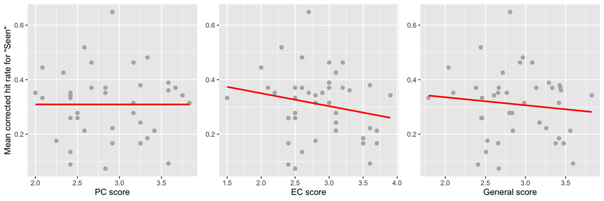

```
##
##  Pearson's product-moment correlation
##
## data:  inside.hit.rate.trait.novel$meanSrcAcc and inside.hit.rate.trait.novel$PC
## t = -0.0034926, df = 39, p-value = 0.9972
## alternative hypothesis: true correlation is not equal to 0
## 95 percent confidence interval:
##  -0.3081567  0.3071440
## sample estimates:
##           cor
## -0.0005592631
```

```
##
##  Pearson's product-moment correlation
##
## data:  inside.hit.rate.trait.novel$meanSrcAcc and inside.hit.rate.trait.novel$EC
## t = -1.2745, df = 39, p-value = 0.21
## alternative hypothesis: true correlation is not equal to 0
## 95 percent confidence interval:
##  -0.4781997  0.1147411
## sample estimates:
##        cor
## -0.1999682
```

```
##
##  Pearson's product-moment correlation
##
## data:  inside.hit.rate.trait.novel$meanSrcAcc and inside.hit.rate.trait.novel$GN
## t = -0.70316, df = 39, p-value = 0.4861
## alternative hypothesis: true correlation is not equal to 0
## 95 percent confidence interval:
##  -0.4055782  0.2027404
## sample estimates:
##        cor
## -0.1118889
```

# 5 Relationship between trait score and curiosity ratings between *Familiar* and *Novel* rooms

Here *performance difference* refers to difference in item recollection and source memory between the *novel* and *familiar* rooms (*novel* - *familiar*).

## 5.1 See whether the curiosity ratings are significantly different between *novel* and *familiar* rooms

The average curiosity rating for the *novel* rooms is 5.36 (SD = $\pm$ 1.25).

The average curiosity rating for the *familiar* rooms is 3.5 (SD = $\pm$ 1.69).

```
##
##  One Sample t-test
##
## data:  outside.hit.rate.trait.diff$diffRating
## t = 4.9375, df = 37, p-value = 1.711e-05
## alternative hypothesis: true mean is not equal to 0
## 95 percent confidence interval:
##  1.093923 2.616603
## sample estimates:
## mean of x
##  1.855263
```

## 5.2 See whether the difference in curiosity ratings are significantly correlated with trait scores

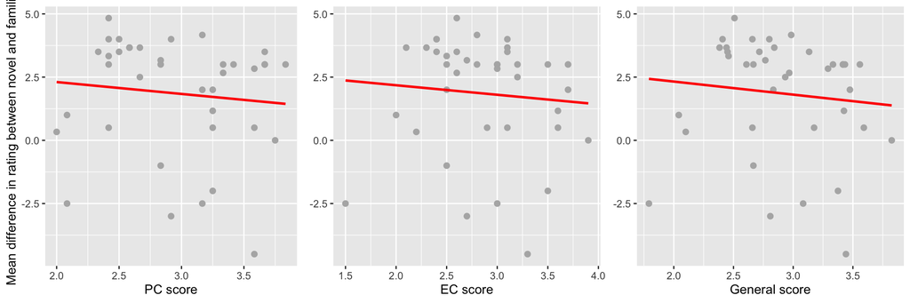

```
##
##  Pearson's product-moment correlation
##
## data:  outside.hit.rate.trait.diff$diffRating and outside.hit.rate.trait.diff$PC
## t = -0.64511, df = 36, p-value = 0.5229
## alternative hypothesis: true correlation is not equal to 0
## 95 percent confidence interval:
##  -0.4124892  0.2203098
## sample estimates:
##        cor
## -0.1069027
```

```
##
##  Pearson's product-moment correlation
##
## data:  outside.hit.rate.trait.diff$diffRating and outside.hit.rate.trait.diff$EC
## t = -0.52152, df = 36, p-value = 0.6052
## alternative hypothesis: true correlation is not equal to 0
## 95 percent confidence interval:
##  -0.3953331  0.2397260
## sample estimates:
##         cor
## -0.08659356
```

```
##
##  Pearson's product-moment correlation
##
## data:  outside.hit.rate.trait.diff$diffRating and outside.hit.rate.trait.diff$GN
## t = -0.64478, df = 36, p-value = 0.5232
## alternative hypothesis: true correlation is not equal to 0
## 95 percent confidence interval:
##  -0.4124439  0.2203617
## sample estimates:
##        cor
## -0.1068487
```

### 5.2.1 Looking at the trait-rating correlation separately for the *novel* and *familiar* rooms

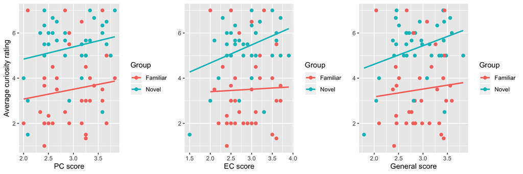

# 6 Relationship between trait score and performance differences between *Familiar* and *Novel* rooms

Here *performance difference* refers to difference in item recollection and source memory between the *novel* and *familiar* rooms (*novel* - *familiar*).

## 6.1 Outside

### 6.1.1 Item recollection

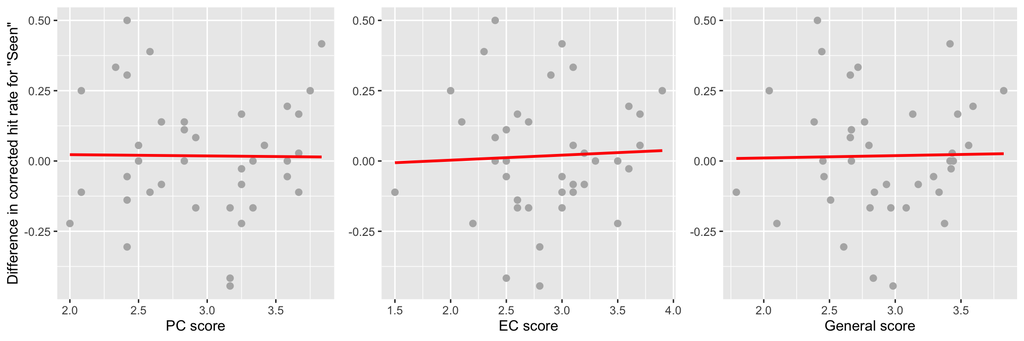

### 6.1.2 Source memory

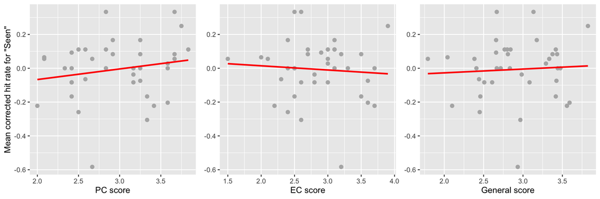

```
##
##  Pearson's product-moment correlation
##
## data:  outside.hit.rate.trait.diff$diffSrcAcc and outside.hit.rate.trait.diff$PC
## t = 1.1381, df = 36, p-value = 0.2626
## alternative hypothesis: true correlation is not equal to 0
## 95 percent confidence interval:
##  -0.1417700  0.4775899
## sample estimates:
##       cor
## 0.1863595
```

```
##
##  Pearson's product-moment correlation
##
## data:  outside.hit.rate.trait.diff$diffSrcAcc and outside.hit.rate.trait.diff$EC
## t = -0.4504, df = 36, p-value = 0.6551
## alternative hypothesis: true correlation is not equal to 0
## 95 percent confidence interval:
##  -0.3853185  0.2508299
## sample estimates:
##         cor
## -0.07485589
```

```
##
##  Pearson's product-moment correlation
##
## data:  outside.hit.rate.trait.diff$diffSrcAcc and outside.hit.rate.trait.diff$GN
## t = 0.36588, df = 36, p-value = 0.7166
## alternative hypothesis: true correlation is not equal to 0
## 95 percent confidence interval:
##  -0.2639531  0.3732862
## sample estimates:
##        cor
## 0.06086618
```

## 6.2 Inside

### 6.2.1 Item recollection

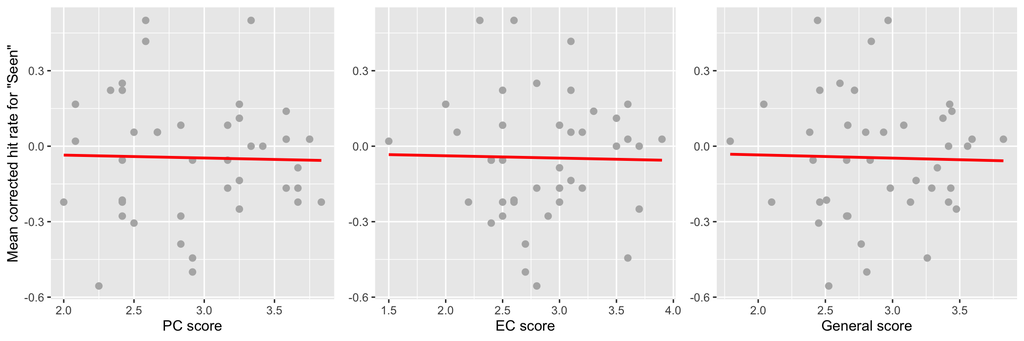

```
##
##  Pearson's product-moment correlation
##
## data:  inside.hit.rate.trait.diff$diffSAcc and inside.hit.rate.trait.diff$PC
## t = -0.15255, df = 39, p-value = 0.8795
## alternative hypothesis: true correlation is not equal to 0
## 95 percent confidence interval:
##  -0.3295938  0.2853748
## sample estimates:
##         cor
## -0.02441953
```

```
##
##  Pearson's product-moment correlation
##
## data:  inside.hit.rate.trait.diff$diffSAcc and inside.hit.rate.trait.diff$EC
## t = -0.12303, df = 39, p-value = 0.9027
## alternative hypothesis: true correlation is not equal to 0
## 95 percent confidence interval:
##  -0.3253749  0.2897098
## sample estimates:
##         cor
## -0.01969612
```

```
##
##  Pearson's product-moment correlation
##
## data:  inside.hit.rate.trait.diff$diffSAcc and inside.hit.rate.trait.diff$GN
## t = -0.15323, df = 39, p-value = 0.879
## alternative hypothesis: true correlation is not equal to 0
## 95 percent confidence interval:
##  -0.3296918  0.2852739
## sample estimates:
##         cor
## -0.02452934
```

### 6.2.2 Source memory

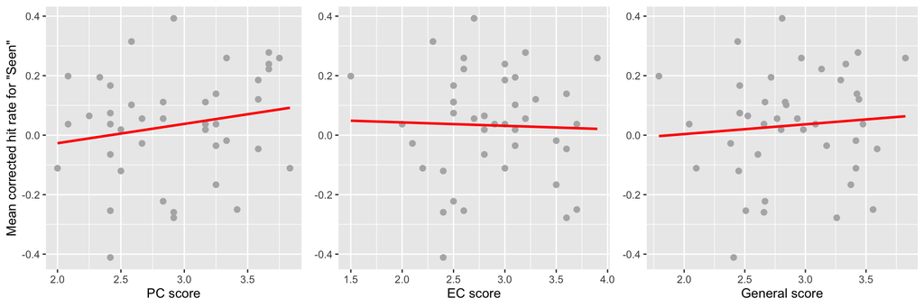

```
##
##  Pearson's product-moment correlation
##
## data:  inside.hit.rate.trait.diff$diffSrcAcc and inside.hit.rate.trait.diff$PC
## t = 1.1911, df = 39, p-value = 0.2408
## alternative hypothesis: true correlation is not equal to 0
## 95 percent confidence interval:
##  -0.1276532  0.4680285
## sample estimates:
##       cor
## 0.1873552
```

```
##
##  Pearson's product-moment correlation
##
## data:  inside.hit.rate.trait.diff$diffSrcAcc and inside.hit.rate.trait.diff$EC
## t = -0.20712, df = 39, p-value = 0.837
## alternative hypothesis: true correlation is not equal to 0
## 95 percent confidence interval:
##  -0.3373582  0.2773306
## sample estimates:
##        cor
## -0.0331481
```

```
##
##  Pearson's product-moment correlation
##
## data:  inside.hit.rate.trait.diff$diffSrcAcc and inside.hit.rate.trait.diff$GN
## t = 0.53516, df = 39, p-value = 0.5956
## alternative hypothesis: true correlation is not equal to 0
## 95 percent confidence interval:
##  -0.2282646  0.3829724
## sample estimates:
##        cor
## 0.08538181
```